# Daily Weather Data

# Temporal coverage

Coverage of the timeseries can be calculated using `coverage()`.

```r
station_coverage <- coverage(daily_ts)
station_coverage
```

```
#> # A tibble: 515 × 6
#>    station      year month monthly_coverage_tmax annual_coverage_tmax
#>    <chr>       <dbl> <dbl>                 <dbl>                <dbl>
#>  1 CA003076680  2002    11                 0.133                0.426
#>  2 CA003076680  2002    12                 0.710                0.426
#>  3 CA003076680  2003     1                 0.871                0.937
#>  4 CA003076680  2003     2                 0.929                0.937
#>  5 CA003076680  2003     3                 0.839                0.937
#>  6 CA003076680  2003     4                 0.867                0.937
#>  7 CA003076680  2003     5                 0.935                0.937
#>  8 CA003076680  2003     6                 1                    0.937
#>  9 CA003076680  2003     7                 1                    0.937
#> 10 CA003076680  2003     8                 1                    0.937
#> # ℹ 505 more rows
#> # ℹ 1 more variable: period_coverage_tmax <dbl>
```

`period_coverage_*` calculates the coverage across the whole period, including missing years.

```r
unique(station_coverage[
  station_coverage$annual_coverage_tmax < .95,
  c("station", "year", "annual_coverage_tmax")
])
```

```
#> # A tibble: 11 × 3
#>    station      year annual_coverage_tmax
#>    <chr>       <dbl>                <dbl>
#>  1 CA003076680  2002                0.426
#>  2 CA003076680  2003                0.937
#>  3 CA003076680  2004                0.929
#>  4 CA003076680  2010                0.942
#>  5 CA003076680  2012                0.918
#>  6 CA003076680  2013                0.901
#>  7 CA003076680  2016                0.825
#>  8 CA003076680  2017                0.882
#>  9 CA003076680  2023                0.868
#> 10 CA003076680  2024                0.885
#> 11 USC00010655  2007                0.912
```

# Monthly and annual timeseries, climatological normals

The functions `monthly()`, `quarterly()`, and `annual()` summarized the weather time series to monthly, quarterly, and annual time series, respectively. Summaries are calculated as follows:

- $T_{min}$ is the minimum daily temperature recorded in the month or the year.
- $T_{max}$ is the maximum daily temperature recorded in the month or the year.
- $Prcp$ is the cumulative precipitation during the month or year.

`NA`s are removed during calculation.

```r
monthly_ts <- monthly(daily_ts)
monthly_ts
```

```
#> # A tibble: 515 × 4
#>    station      year month  tmax
#>  * <chr>       <dbl> <dbl> <dbl>
#>  1 CA003076680  2002    11   6.5
#>  2 CA003076680  2002    12   7.2
#>  3 CA003076680  2003     1  16.1
#>  4 CA003076680  2003     2   4.4
#>  5 CA003076680  2003     3  12.5
#>  6 CA003076680  2003     4  18.9
#>  7 CA003076680  2003     5  27.6
#>  8 CA003076680  2003     6  27.6
#>  9 CA003076680  2003     7  31.4
#> 10 CA003076680  2003     8  32.1
#> # ℹ 505 more rows
```

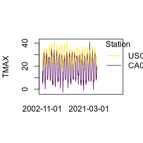

```r
plot(monthly_ts, "tmax")
```

```r
quarterly_ts <- quarterly(daily_ts)
quarterly_ts
```

```
#> # A tibble: 174 × 4
#>    station      year quarter  tmax
#>  * <chr>       <dbl>   <dbl> <dbl>
#>  1 CA003076680  2002       4   7.2
#>  2 CA003076680  2003       1  16.1
#>  3 CA003076680  2003       2  27.6
#>  4 CA003076680  2003       3  32.1
#>  5 CA003076680  2003       4  29.6
#>  6 CA003076680  2004       1  16
#>  7 CA003076680  2004       2  28.3
#>  8 CA003076680  2004       3  31.4
#>  9 CA003076680  2004       4  23.1
#> 10 CA003076680  2005       1  13.7
#> # ℹ 164 more rows
```

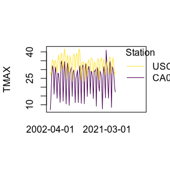

```r
plot(quarterly_ts, "tmax")
```

```r
annual_ts <- annual(daily_ts)
annual_ts
```

```
#> # A tibble: 46 × 3
#>    station      year  tmax
#>  * <chr>       <dbl> <dbl>
#>  1 CA003076680  2002   7.2
#>  2 CA003076680  2003  32.1
#>  3 CA003076680  2004  31.4
#>  4 CA003076680  2005  28
#>  5 CA003076680  2006  34.8
#>  6 CA003076680  2007  34.5
#>  7 CA003076680  2008  33.6
#>  8 CA003076680  2009  31.3
#>  9 CA003076680  2010  29.7
#> 10 CA003076680  2011  29.6
#> # ℹ 36 more rows
```

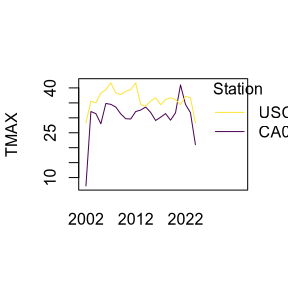

```r
plot(annual_ts, "tmax")
```